# Data Management Final Project

Adeline Shelby

11/30/2023

### Introduction and Methods Overview

This is an R Markdown document created for the final project for the Data Management/GIS course. It includes data and pictures from my thesis titled: “**Assessing the adaptive response of reciprocally outplanted *Orbicella annularis* along nearshore and offshore reefs in St Thomas, US Virgin Islands**”. 32 parent colonies across 4 sites (2 turbid nearshore and 2 clear offshore locations) were sampled via fragmentation in February 2023. These fragments were then outplanted along their natal reefs and the other corresponding foreign reefs, i.e. a reciprocal outplant. Every month for 12-months, environmental parameters and coral health/survivability are monitored. The objectives of this study are to 1) be able to measure and quantify the environmental characteristics across four sites and 2) assess and understand the differences in physiological reaction of outplanted coral.

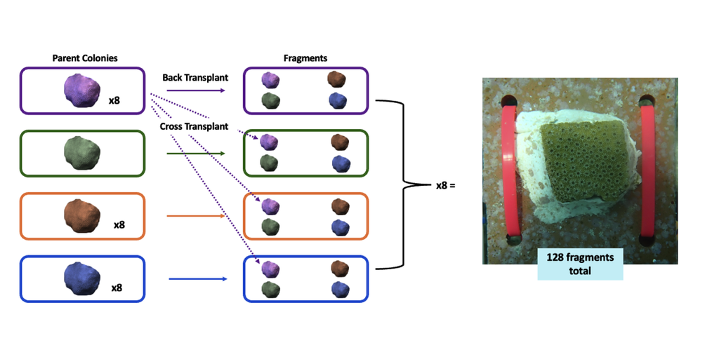

Figure 1. Simplified diagram of reciprocal transplant methods

### Preliminary Data

Below I have included bar graphs of the health data of my fragments across the 4 experimental sites. This is only a snapshot of what they were exhibiting in late October (8 months into the study) after the heat stress from the summer months.

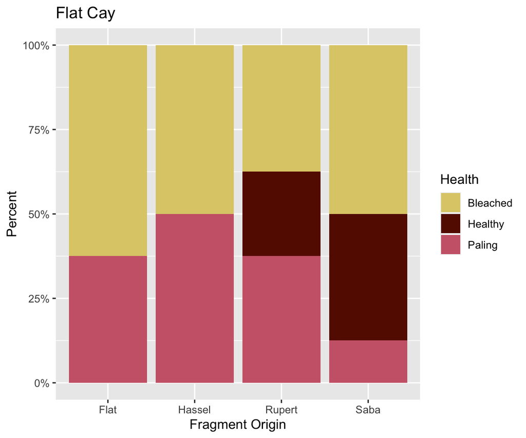

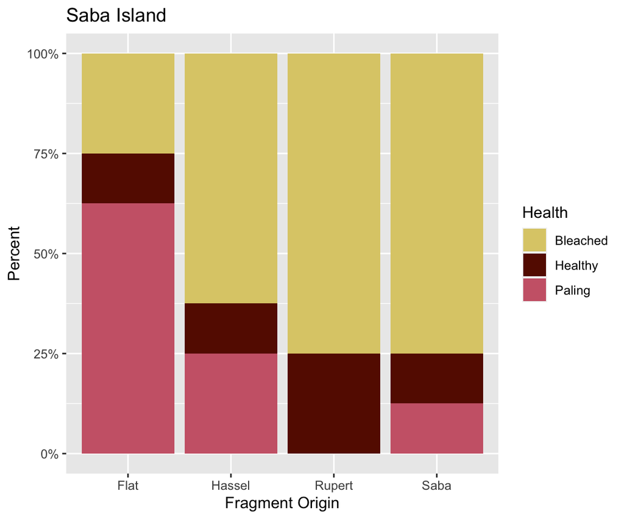

Figure 2. and Figure 3. Fragment health data from October within clear offshore sites; Flat Cay and Saba Island. Bleaching is seen across all coral, but coral sourced from Rupert’s Rock and Saba Island have a (slightly) higher amount of apparently healthy fragments.

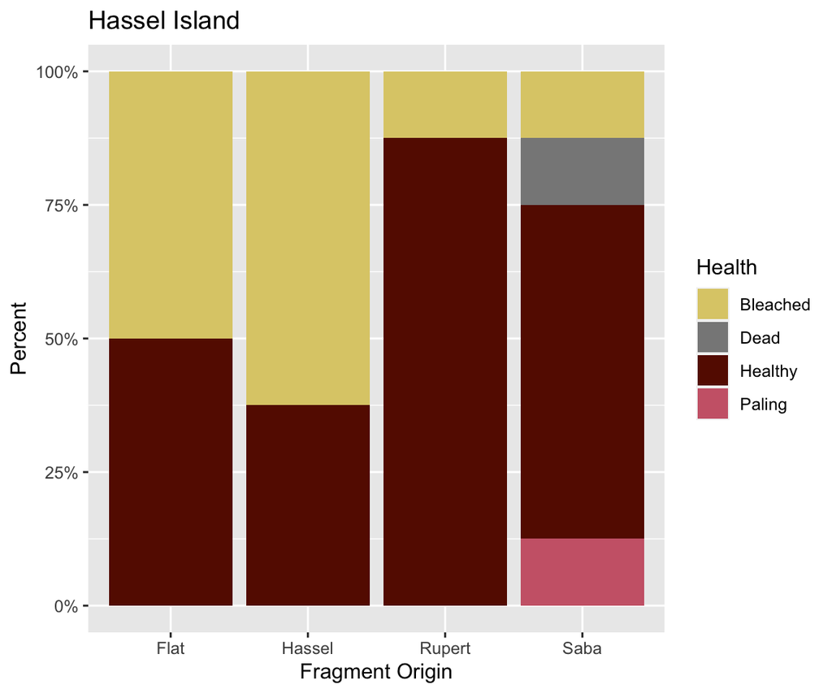

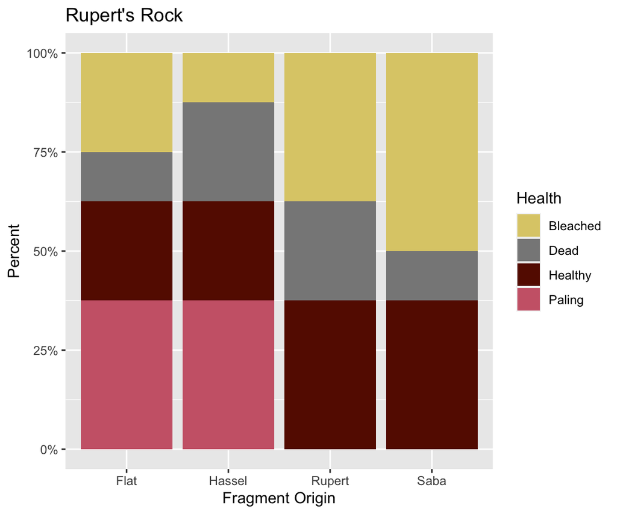

Figure 4. and Figure 5. Fragment health data from October within turbid nearshore sites; Hassel Island and Rupert’s Rock. Most mortality has occurred at Rupert’s Rock and is exhibited by coral from all 4 sites. At Hassel Island there is the highest amount of apparently healthy fragments.

### Early Conclusions

It is interesting how much can change each month. At the halfway mark of my project, coral sourced from Hassel Island had remained healthy across all 4 sites. Given its heartiness, I was ready to suggest we use coral from areas comparable to Hassel for restoration projects. That was premature, however, as we hadn’t yet seen the impacts of the summer bleaching event. At 8 months, things seem less conclusive. But I still have lots of growth, HOBO, and PAR data to go through and analyze (-: so the answers might be hidden there.